# Dev Mid-Term Submission

Step 1: Calling Necessary Packages

```r
library(ISLR)
library(dplyr)
library(caret)
library(tidyverse)
library(factoextra)
library(flexclust)
library(imputeTS)
```

Step 2: Reading the Data

```r
data <- read.csv("C:/Users/BrandRely/Documents/Datasets/Universities.csv")

head(data)
```

|  | College.Name | State | Public..1...Private..2. | X..appli..rec.d | X..appl..accepted | X..new.stud..enrolled | X..new.stud..from.top.10. | X..new.stud..from.top.25. | X..FT.undergrad | X..PT.undergrad | in.state.tuition | out.of.state.tuition | room | board | add..fees | estim..book.costs | estim..personal.. | X..fac..w.PHD | stud..fac..ratio | Graduation.rate |
| --- | --- | --- | --- | --- | --- | --- | --- | --- | --- | --- | --- | --- | --- | --- | --- | --- | --- | --- | --- | --- |
| 1 | Alaska Pacific University | AK | 2 | 193 | 146 | 55 | 16 | 44 | 249 | 869 | 7560 | 7560 | 1620 | 2500 | 130 | 800 | 1500 | 76 | 11.9 | 15 |
| 2 | University of Alaska at Fairbanks | AK | 1 | 1852 | 1427 | 928 | NA | NA | 3885 | 4519 | 1742 | 5226 | 1800 | 1790 | 155 | 650 | 2304 | 67 | 10.0 | NA |
| 3 | University of Alaska Southeast | AK | 1 | 146 | 117 | 89 | 4 | 24 | 492 | 1849 | 1742 | 5226 | 2514 | 2250 | 34 | 500 | 1162 | 39 | 9.5 | 39 |
| 4 | University of Alaska at Anchorage | AK | 1 | 2065 | 1598 | 1162 | NA | NA | 6209 | 10537 | 1742 | 5226 | 2600 | 2520 | 114 | 580 | 1260 | 48 | 13.7 | NA |
| 5 | Alabama Agri. & Mech. Univ. | AL | 1 | 2817 | 1920 | 984 | NA | NA | 3958 | 305 | 1700 | 3400 | 1108 | 1442 | 155 | 500 | 850 | 53 | 14.3 | 40 |
| 6 | Faulkner University | AL | 2 | 345 | 320 | 179 | NA | 27 | 1367 | 578 | 5600 | 5600 | 1550 | 1700 | 300 | 350 | NA | 52 | 32.8 | 55 |

(Question - 1) Step 3: Deleting records with missing measurements & separating continous variables

```r
data_omit <- na.omit(data)

data_with_cont_var <- data_omit[-c(1, 2, 3) ]

head(data_with_cont_var)
```

|  | X..appli..rec.d | X..appl..accepted | X..new.stud..enrolled | X..new.stud..from.top.10. | X..new.stud..from.top.25. | X..FT.undergrad | X..PT.undergrad | in.state.tuition | out.of.state.tuition | room | board | add..fees | estim..book.costs | estim..personal.. | X..fac..w.PHD | stud..fac..ratio | Graduation.rate |
| --- | --- | --- | --- | --- | --- | --- | --- | --- | --- | --- | --- | --- | --- | --- | --- | --- | --- |
| 1 | 193 | 146 | 55 | 16 | 44 | 249 | 869 | 7560 | 7560 | 1620 | 2500 | 130 | 800 | 1500 | 76 | 11.9 | 15 |
| 3 | 146 | 117 | 89 | 4 | 24 | 492 | 1849 | 1742 | 5226 | 2514 | 2250 | 34 | 500 | 1162 | 39 | 9.5 | 39 |
| 10 | 805 | 588 | 287 | 67 | 88 | 1376 | 207 | 11660 | 11660 | 2050 | 2430 | 120 | 400 | 900 | 74 | 14.0 | 72 |
| 12 | 608 | 520 | 127 | 26 | 47 | 538 | 126 | 8080 | 8080 | 1380 | 2540 | 100 | 500 | 1100 | 63 | 11.4 | 44 |
| 22 | 4414 | 1500 | 335 | 30 | 60 | 908 | 119 | 5666 | 5666 | 1424 | 1540 | 418 | 1000 | 1400 | 56 | 15.5 | 46 |
| 26 | 1797 | 1260 | 938 | 24 | 35 | 6960 | 4698 | 2220 | 4440 | 1935 | 3240 | 291 | 750 | 2200 | 96 | 6.7 | 33 |

(Question - 2) Step 4: Normalization the Data

```r
set.seed(123)
data_norm <- preProcess(data_with_cont_var, method=c("center", "scale"))
data_norm <- predict(data_norm,data_with_cont_var)
head(data_norm)
```

|  | X..appli..rec.d | X..appl..accepted | X..new.stud..enrolled | X..new.stud..from.top.10. | X..new.stud..from.top.25. | X..FT.undergrad | X..PT.undergrad | in.state.tuition | out.of.state.tuition | room | board | add..fees | estim..book.costs | estim..personal.. | X..fac..w.PHD | stud..fac..ratio | Graduation.rate |
| --- | --- | --- | --- | --- | --- | --- | --- | --- | --- | --- | --- | --- | --- | --- | --- | --- | --- |
| 1 | -0.7253139 | -0.7656329 | -0.7925715 | -0.6500683 | -0.5732933 | -0.7097404 | 0.0462840 | -0.3347297 | -0.6993021 | -0.8428467 | 0.6669350 | -0.6997824 | 1.5394532 | 0.2758088 | 0.16752615 | -0.529035524 | -2.7862940 |
| 3 | -0.7368529 | -0.7772155 | -0.7554388 | -1.2994472 | -1.5573355 | -0.6576975 | 0.6802614 | -1.3893276 | -1.2406234 | 0.4106795 | 0.2259098 | -0.9695550 | -0.2989446 | -0.2199034 | -2.05260943 | -1.144600894 | -1.4637549 |
| 10 | -0.5750612 | -0.5890979 | -0.5391950 | 2.1097921 | 1.5915994 | -0.4683728 | -0.3819742 | 0.4084555 | 0.2516051 | -0.2399203 | 0.5434479 | -0.7278837 | -0.9117438 | -0.6041537 | 0.04751883 | 0.009584174 | 0.3547362 |
| 12 | -0.6234268 | -0.6162571 | -0.7139374 | -0.1089192 | -0.4256870 | -0.6478457 | -0.4343744 | -0.2404720 | -0.5786992 | -1.1793639 | 0.7374990 | -0.7840863 | -0.2989446 | -0.3108329 | -0.61252148 | -0.657278310 | -1.1882260 |
| 22 | 0.3109878 | -0.2248447 | -0.4867723 | 0.1075405 | 0.2139404 | -0.5686035 | -0.4389028 | -0.6780450 | -1.1385749 | -1.1176691 | -1.0266018 | 0.1095355 | 2.7650518 | 0.1291484 | -1.03254714 | 0.394312530 | -1.0780144 |
| 26 | -0.3315143 | -0.3207008 | 0.1717883 | -0.2171490 | -1.0161123 | 0.7275427 | 2.5233243 | -1.3026831 | -1.4229193 | -0.4011680 | 1.9723696 | -0.2473512 | 1.2330536 | 1.3024317 | 1.36759945 | -1.862760492 | -1.7943897 |

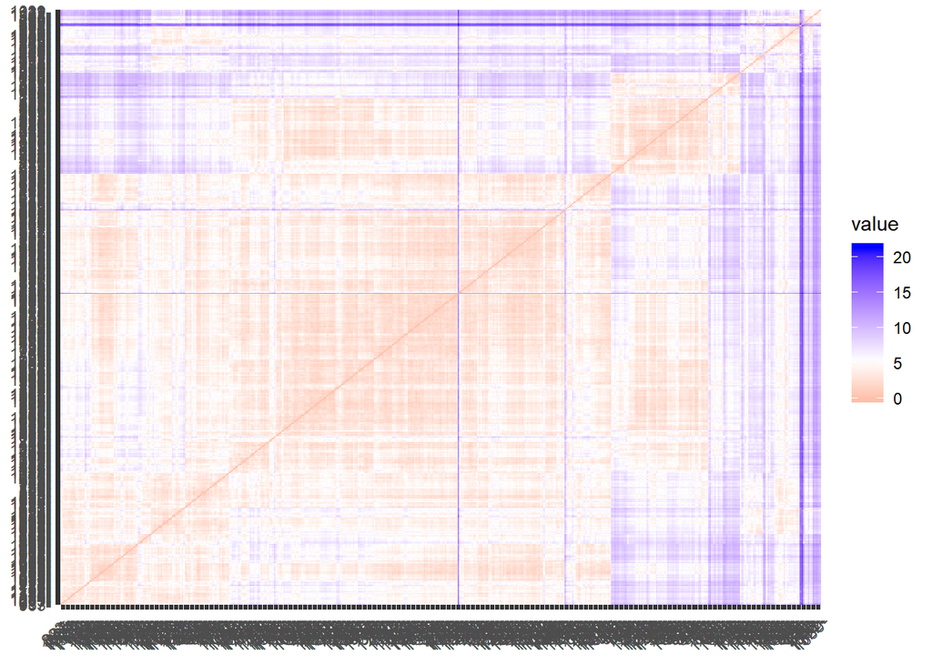

```r
dist <- get_dist(data_norm)
fviz_dist(dist)
```

Step 6: Using K-Means clustering algorithm with K = 5 & K = 3 as it seems reasonable & will give us a good idea

```r
k5 <- kmeans(data_norm, centers = 5, nstart = 25 )
k5
```

```
## K-means clustering with 5 clusters of sizes 83, 150, 141, 60, 37
##
## Cluster means:
##   X..appli..rec.d X..appl..accepted X..new.stud..enrolled
## 1       0.1682069         0.2029277            0.37049207
## 2      -0.3426507        -0.2983104           -0.37339353
## 3      -0.5569125        -0.5531207           -0.54647592
## 4       0.5133052         0.1878958            0.04207847
## 5       2.3016968         2.5572926            2.69693471
##   X..new.stud..from.top.10. X..new.stud..from.top.25. X..FT.undergrad
## 1                -0.5783497                -0.4956370      0.44673975
## 2                 0.1396486                 0.2637985     -0.39038553
## 3                -0.6251217                -0.7320661     -0.52891250
## 4                 1.7941218                 1.5251765     -0.07715163
## 5                 0.2040698                 0.3588871      2.72119433
```

[output cut: 94 more lines]

```r
k3 <- kmeans(data_norm, centers = 3, nstart = 25 )
k3
```

```
## K-means clustering with 3 clusters of sizes 46, 150, 275
##
## Cluster means:
##   X..appli..rec.d X..appl..accepted X..new.stud..enrolled
## 1      1.98179657        2.22992267             2.4447222
## 2      0.05140256       -0.04367128            -0.1683551
## 3     -0.35953828       -0.34918455            -0.3171053
##   X..new.stud..from.top.10. X..new.stud..from.top.25. X..FT.undergrad
## 1                 0.1334215                 0.2545856       2.5228452
## 2                 0.8795798                 0.8620961      -0.2324464
## 3                -0.5020886                -0.5128195      -0.2952142
##   X..PT.undergrad in.state.tuition out.of.state.tuition       room
## 1       1.7486849       -1.0500277           -0.4918168 -0.0388330
## 2      -0.3130216        1.0620416            1.1158839  0.6698444
## 3      -0.1217682       -0.4036544           -0.5263964 -0.3588740
```

[output cut: 84 more lines]

Step 7: Displaying Center & Size of the Clusters

```r
#For K = 5
k5$cluster
```

```
##    1    3   10   12   22   26   32   38   39   46   49   50   63   77   78
##    3    3    2    3    3    1    2    2    3    1    1    5    1    4    4
##   79   81   90   92   95   96   97  108  110  112  120  121  122  123  126
##    4    4    4    2    4    3    2    2    5    2    2    2    1    4    1
##  127  130  134  139  140  146  148  149  151  152  153  154  156  158  160
##    1    1    1    1    4    2    2    4    2    2    4    1    5    2    4
##  161  164  168  169  172  174  176  181  186  188  190  194  208  210  220
##    4    2    5    3    3    2    3    3    2    2    4    5    3    4    2
##  228  230  235  236  239  244  245  246  247  248  250  251  252  258  259
##    2    5    3    3    1    2    3    2    2    3    3    3    4    3    3
##  260  262  263  264  265  268  269  270  272  275  277  287  294  297  298
##    3    2    3    1    3    2    3    3    2    3    2    3    2    2    2
##  302  304  312  317  319  320  321  322  323  324  326  329  330  331  332
##    3    2    2    1    2    3    4    5    5    1    3    2    2    2    2
##  333  336  340  349  352  359  360  362  365  366  368  369  370  376  377
```

[output cut: 49 more lines]

```r
k5$centers
```

```
##   X..appli..rec.d X..appl..accepted X..new.stud..enrolled
## 1       0.1682069         0.2029277            0.37049207
## 2      -0.3426507        -0.2983104           -0.37339353
## 3      -0.5569125        -0.5531207           -0.54647592
## 4       0.5133052         0.1878958            0.04207847
## 5       2.3016968         2.5572926            2.69693471
##   X..new.stud..from.top.10. X..new.stud..from.top.25. X..FT.undergrad
## 1                -0.5783497                -0.4956370      0.44673975
## 2                 0.1396486                 0.2637985     -0.39038553
## 3                -0.6251217                -0.7320661     -0.52891250
## 4                 1.7941218                 1.5251765     -0.07715163
## 5                 0.2040698                 0.3588871      2.72119433
##   X..PT.undergrad in.state.tuition out.of.state.tuition       room
## 1       0.3577778       -1.2804094           -1.0816909 -0.4494664
## 2      -0.2741592        0.5591155            0.4758599  0.1946075
## 3      -0.2502879       -0.2224986           -0.4869970 -0.4735431
## 4      -0.3735320        1.5152395            1.7021870  1.2108424
## 5       1.8684008       -1.0036600           -0.4071160  0.0603682
##         board  add..fees estim..book.costs estim..personal.. X..fac..w.PHD
## 1 -0.71584374  0.5456475       -0.02813158        0.37150911     0.0713757
## 2  0.39150003 -0.1345900       -0.12879063       -0.30974761     0.3363365
## 3 -0.41288238 -0.4013105       -0.04908761        0.07727633    -1.0623362
## 4  1.03863100  0.1320633        0.33234082       -0.47423704     1.0915826
## 5 -0.09220051  0.6367769        0.23336269        0.89689582     0.7545890
##   stud..fac..ratio Graduation.rate
## 1       1.00678771      -0.6683725
## 2      -0.27596976       0.4447424
## 3       0.06652033      -0.5386811
## 4      -1.16554722       1.1647914
## 5       0.49690676      -0.1397266
```

```r
k5$size
```

```
## [1]  83 150 141  60  37
```

```r
#For K = 3
k3$cluster
```

```
##    1    3   10   12   22   26   32   38   39   46   49   50   63   77   78
##    3    3    2    3    3    3    3    3    3    3    1    1    1    2    2
##   79   81   90   92   95   96   97  108  110  112  120  121  122  123  126
##    2    2    2    3    2    3    2    2    1    2    2    3    3    2    3
##  127  130  134  139  140  146  148  149  151  152  153  154  156  158  160
##    3    3    3    3    2    3    2    2    2    2    2    3    1    2    2
##  161  164  168  169  172  174  176  181  186  188  190  194  208  210  220
##    2    2    1    3    3    2    3    3    2    2    2    1    3    2    3
##  228  230  235  236  239  244  245  246  247  248  250  251  252  258  259
##    2    1    3    3    3    3    3    3    2    3    3    3    2    3    3
##  260  262  263  264  265  268  269  270  272  275  277  287  294  297  298
##    3    3    3    3    3    3    3    3    3    3    2    3    2    2    2
##  302  304  312  317  319  320  321  322  323  324  326  329  330  331  332
##    3    2    3    3    3    3    2    1    1    3    3    2    2    2    3
##  333  336  340  349  352  359  360  362  365  366  368  369  370  376  377
```

[output cut: 49 more lines]

```r
k3$centers
```

```
##   X..appli..rec.d X..appl..accepted X..new.stud..enrolled
## 1      1.98179657        2.22992267             2.4447222
## 2      0.05140256       -0.04367128            -0.1683551
## 3     -0.35953828       -0.34918455            -0.3171053
##   X..new.stud..from.top.10. X..new.stud..from.top.25. X..FT.undergrad
## 1                 0.1334215                 0.2545856       2.5228452
## 2                 0.8795798                 0.8620961      -0.2324464
## 3                -0.5020886                -0.5128195      -0.2952142
##   X..PT.undergrad in.state.tuition out.of.state.tuition       room
## 1       1.7486849       -1.0500277           -0.4918168 -0.0388330
## 2      -0.3130216        1.0620416            1.1158839  0.6698444
## 3      -0.1217682       -0.4036544           -0.5263964 -0.3588740
##        board   add..fees estim..book.costs estim..personal.. X..fac..w.PHD
## 1 -0.1745795  0.49531762        0.16358567        0.93858632     0.6840794
## 2  0.7756859 -0.04496556        0.07122705       -0.39665857     0.7659627
## 3 -0.3938990 -0.05832646       -0.06621454        0.05935933    -0.5322257
##   stud..fac..ratio Graduation.rate
## 1        0.6139980      -0.2538234
## 2       -0.7036167       0.8426062
## 3        0.2810858      -0.4171456
```

```r
k3$size
```

```
## [1]  46 150 275
```

Step 8: Visualization of the Clusters formed

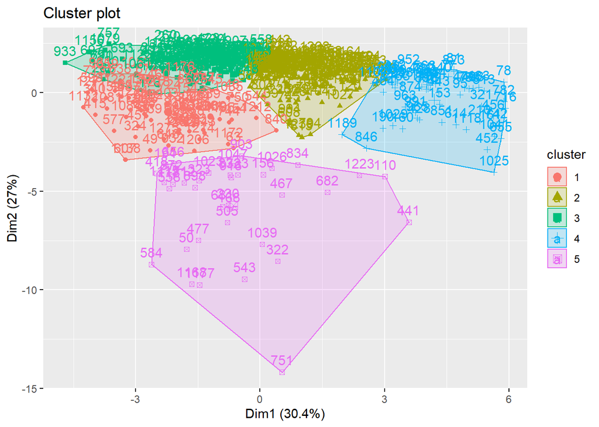

```r
fviz_cluster(k5,data= data_norm)
```

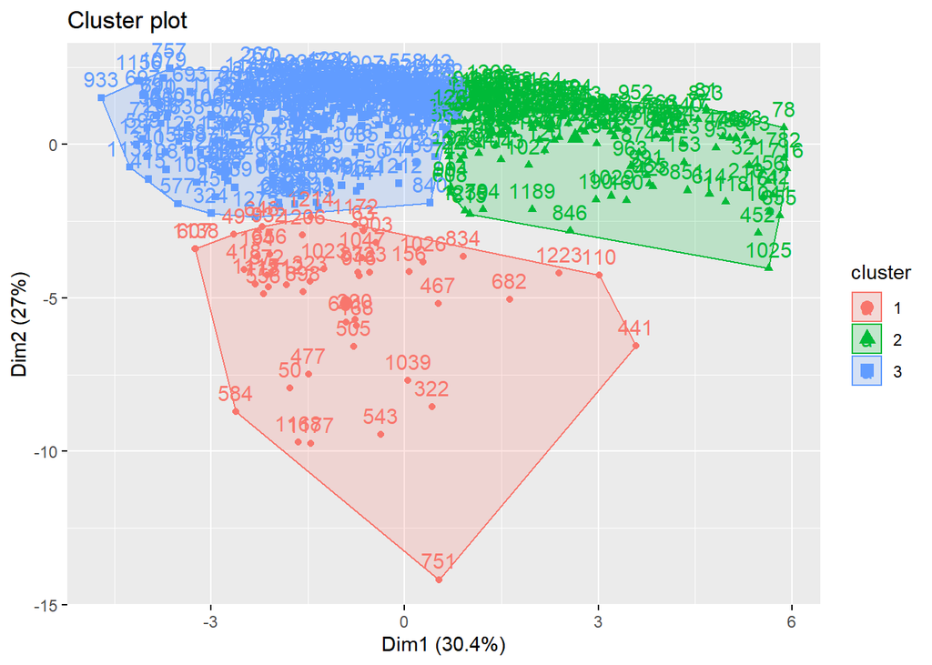

```r
fviz_cluster(k3,data= data_norm)
```

```r
# K = 3 seems to be reasonable as the clustures seems to be grouped well, however in K = 5 there is more clustering than needed according to the spread of data points.
```

Step 9: Testing K for optimal value of K using WSS & Silhouette

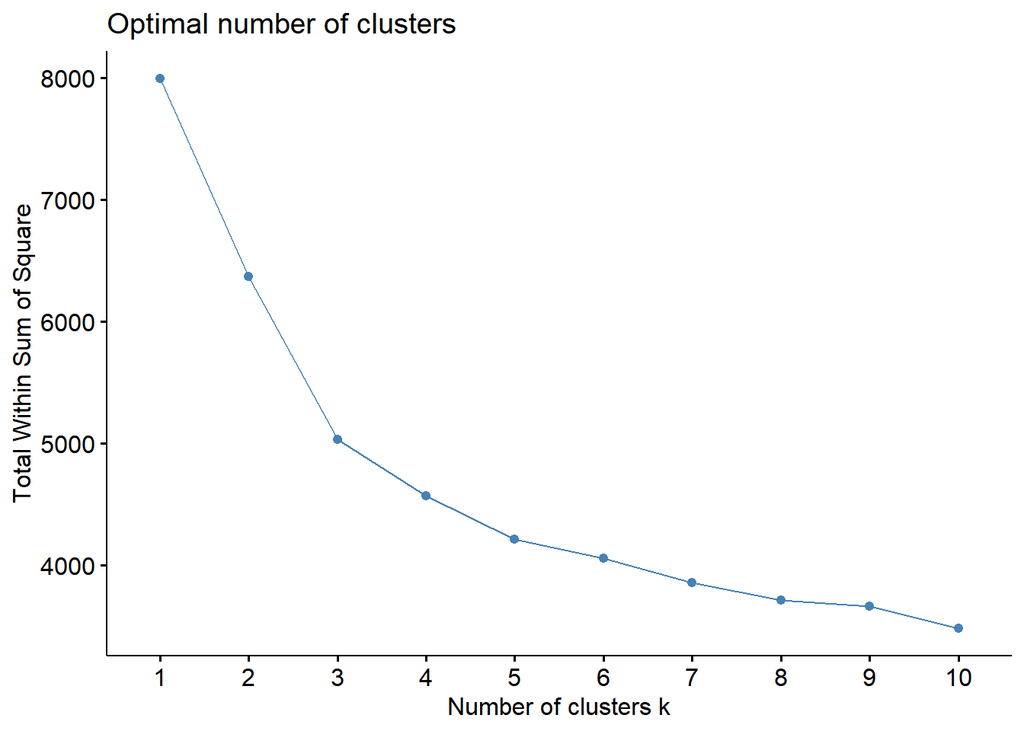

```r
fviz_nbclust(data_norm,kmeans,method = "wss")
```

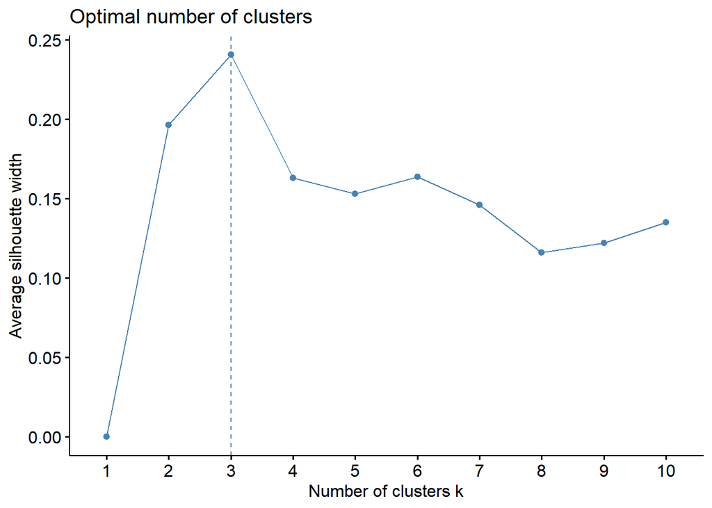

```r
fviz_nbclust(data_norm,kmeans,method = "silhouette")
```

```r
# The graphs clearly tells us K = 3 is the optimal value as we observed previously by looking at the clusters formed.
```

Step 10: Creating cluster Index & Merging to Data Frame

```r
set.seed(123)
dist_k3 = kcca(data_norm, k=3, kccaFamily("kmedians"))
dist_k3
```

```
## kcca object of family 'kmedians'
##
## call:
## kcca(x = data_norm, k = 3, family = kccaFamily("kmedians"))
##
## cluster sizes:
##
##   1   2   3
## 111 113 247
```

```r
dist_clus <- predict(dist_k3)
dist_clus
```

```
##    1    3   10   12   22   26   32   38   39   46   49   50   63   77   78
##    3    3    3    3    3    1    3    3    3    3    1    1    1    2    2
##   79   81   90   92   95   96   97  108  110  112  120  121  122  123  126
##    2    2    2    3    2    3    2    3    2    2    2    3    3    2    1
##  127  130  134  139  140  146  148  149  151  152  153  154  156  158  160
##    1    3    1    1    2    3    3    2    3    3    2    1    1    2    2
##  161  164  168  169  172  174  176  181  186  188  190  194  208  210  220
##    2    3    1    3    3    2    1    3    2    2    2    1    3    2    2
##  228  230  235  236  239  244  245  246  247  248  250  251  252  258  259
##    2    1    3    3    1    3    3    3    3    3    3    3    2    3    3
##  260  262  263  264  265  268  269  270  272  275  277  287  294  297  298
##    3    3    3    1    3    3    3    3    3    3    3    3    2    2    2
##  302  304  312  317  319  320  321  322  323  324  326  329  330  331  332
##    3    3    3    1    3    3    2    1    1    1    3    2    2    2    3
##  333  336  340  349  352  359  360  362  365  366  368  369  370  376  377
```

[output cut: 49 more lines]

```r
set.seed(123)
cluster <- data.frame(dist_clus)
data_omit <- cbind(data_omit, cluster)

colnames(data_omit)
```

```
##  [1] "College.Name"              "State"
##  [3] "Public..1...Private..2."   "X..appli..rec.d"
##  [5] "X..appl..accepted"         "X..new.stud..enrolled"
##  [7] "X..new.stud..from.top.10." "X..new.stud..from.top.25."
##  [9] "X..FT.undergrad"           "X..PT.undergrad"
## [11] "in.state.tuition"          "out.of.state.tuition"
## [13] "room"                      "board"
## [15] "add..fees"                 "estim..book.costs"
## [17] "estim..personal.."         "X..fac..w.PHD"
## [19] "stud..fac..ratio"          "Graduation.rate"
## [21] "dist_clus"
```

```r
head(data_omit)
```

|  | College.Name | State | Public..1...Private..2. | X..appli..rec.d | X..appl..accepted | X..new.stud..enrolled | X..new.stud..from.top.10. | X..new.stud..from.top.25. | X..FT.undergrad | X..PT.undergrad | in.state.tuition | out.of.state.tuition | room | board | add..fees | estim..book.costs | estim..personal.. | X..fac..w.PHD | stud..fac..ratio | Graduation.rate | dist_clus |
| --- | --- | --- | --- | --- | --- | --- | --- | --- | --- | --- | --- | --- | --- | --- | --- | --- | --- | --- | --- | --- | --- |
| 1 | Alaska Pacific University | AK | 2 | 193 | 146 | 55 | 16 | 44 | 249 | 869 | 7560 | 7560 | 1620 | 2500 | 130 | 800 | 1500 | 76 | 11.9 | 15 | 3 |
| 3 | University of Alaska Southeast | AK | 1 | 146 | 117 | 89 | 4 | 24 | 492 | 1849 | 1742 | 5226 | 2514 | 2250 | 34 | 500 | 1162 | 39 | 9.5 | 39 | 3 |
| 10 | Birmingham-Southern College | AL | 2 | 805 | 588 | 287 | 67 | 88 | 1376 | 207 | 11660 | 11660 | 2050 | 2430 | 120 | 400 | 900 | 74 | 14.0 | 72 | 3 |
| 12 | Huntingdon College | AL | 2 | 608 | 520 | 127 | 26 | 47 | 538 | 126 | 8080 | 8080 | 1380 | 2540 | 100 | 500 | 1100 | 63 | 11.4 | 44 | 3 |
| 22 | Talladega College | AL | 2 | 4414 | 1500 | 335 | 30 | 60 | 908 | 119 | 5666 | 5666 | 1424 | 1540 | 418 | 1000 | 1400 | 56 | 15.5 | 46 | 3 |
| 26 | University of Alabama at Birmingham | AL | 1 | 1797 | 1260 | 938 | 24 | 35 | 6960 | 4698 | 2220 | 4440 | 1935 | 3240 | 291 | 750 | 2200 | 96 | 6.7 | 33 | 1 |

```r
data_omit$expenses <- data_omit$room + data_omit$board + data_omit$add..fees + data_omit$estim..book.costs + data_omit$estim..personal..
```

(Question - 3) Step 10: Comparing summary statistics for the 3 clusters that are formed

```r
set.seed(123)
stats <- data_omit %>% group_by( dist_clus ) %>%
summarise( Acceptance_Rate = sum(X..appl..accepted)/ sum(X..appli..rec.d), Avg_Out_Of_State_Tuition=mean(out.of.state.tuition), Avg_In_State_Tuition=mean(in.state.tuition), Expenses=mean(expenses), Avg_PHD_Faculty=mean(X..fac..w.PHD), Avg_Student_Faculty_Ratio=mean(stud..fac..ratio), Avg_Graduation_Rate=mean(Graduation.rate), Private_Univs = sum(Public..1...Private..2. == 2), Public_Univs = sum(Public..1...Private..2. == 1))
stats
```

| dist_clus | Acceptance_Rate | Avg_Out_Of_State_Tuition | Avg_In_State_Tuition | Expenses | Avg_PHD_Faculty | Avg_Student_Faculty_Ratio | Avg_Graduation_Rate | Private_Univs | Public_Univs |
| --- | --- | --- | --- | --- | --- | --- | --- | --- | --- |
| 1 | 0.6820287 | 6989.387 | 3030.649 | 6773.234 | 78.20721 | 17.19459 | 57.56757 | 12 | 99 |
| 2 | 0.5484032 | 16358.655 | 16204.673 | 7442.903 | 88.14159 | 10.76283 | 83.06195 | 110 | 3 |
| 3 | 0.7751921 | 9540.692 | 9161.923 | 6103.721 | 64.12955 | 13.97409 | 61.14980 | 221 | 26 |

Describing Clusters for Highest in each category:

```r
stats[which.max(stats$Acceptance_Rate),1:2]
```

| dist_clus | Acceptance_Rate |
| --- | --- |
| 3 | 0.7751921 |

```r
stats[which.max(stats$Avg_Out_Of_State_Tuition),c(1,3)]
```

| dist_clus | Avg_Out_Of_State_Tuition |
| --- | --- |
| 2 | 16358.65 |

```r
stats[which.max(stats$Avg_In_State_Tuition),c(1,4)]
```

| dist_clus | Avg_In_State_Tuition |
| --- | --- |
| 2 | 16204.67 |

```r
stats[which.max(stats$Expenses ),c(1,5)]
```

| dist_clus | Expenses |
| --- | --- |
| 2 | 7442.903 |

```r
stats[which.max(stats$Avg_PHD_Faculty),c(1,6)]
```

| dist_clus | Avg_PHD_Faculty |
| --- | --- |
| 2 | 88.14159 |

```r
stats[which.max(stats$Avg_Student_Faculty_Ratio),c(1,7)]
```

| dist_clus | Avg_Student_Faculty_Ratio |
| --- | --- |
| 1 | 17.19459 |

```r
stats[which.max(stats$Avg_Graduation_Rate ),c(1,8)]
```

| dist_clus | Avg_Graduation_Rate |
| --- | --- |
| 2 | 83.06195 |

```r
stats[which.max(stats$Private_Univs ),c(1,9)]
```

| dist_clus | Private_Univs |
| --- | --- |
| 3 | 221 |

```r
stats[which.max(stats$Public_Univs),c(1,10)]
```

| dist_clus | Public_Univs |
| --- | --- |
| 1 | 99 |

```r
#From these stats we can tell which cluster is the highest in each category
```

Describing Clusters for Lowest in each category:

```r
stats[which.min(stats$Acceptance_Rate),1:2]
```

| dist_clus | Acceptance_Rate |
| --- | --- |
| 2 | 0.5484032 |

```r
stats[which.min(stats$Avg_Out_Of_State_Tuition),c(1,3)]
```

| dist_clus | Avg_Out_Of_State_Tuition |
| --- | --- |
| 1 | 6989.387 |

```r
stats[which.min(stats$Avg_In_State_Tuition),c(1,4)]
```

| dist_clus | Avg_In_State_Tuition |
| --- | --- |
| 1 | 3030.649 |

```r
stats[which.min(stats$Expenses ),c(1,5)]
```

| dist_clus | Expenses |
| --- | --- |
| 3 | 6103.721 |

```r
stats[which.min(stats$Avg_PHD_Faculty),c(1,6)]
```

| dist_clus | Avg_PHD_Faculty |
| --- | --- |
| 3 | 64.12955 |

```r
stats[which.min(stats$Avg_Student_Faculty_Ratio),c(1,7)]
```

| dist_clus | Avg_Student_Faculty_Ratio |
| --- | --- |
| 2 | 10.76283 |

```r
stats[which.min(stats$Avg_Graduation_Rate ),c(1,8)]
```

| dist_clus | Avg_Graduation_Rate |
| --- | --- |
| 1 | 57.56757 |

```r
stats[which.min(stats$Private_Univs ),c(1,9)]
```

| dist_clus | Private_Univs |
| --- | --- |
| 1 | 12 |

```r
stats[which.min(stats$Public_Univs),c(1,10)]
```

| dist_clus | Public_Univs |
| --- | --- |
| 2 | 3 |

```r
#From these stats we can tell which cluster is the lowest in each category
```

(Question - 4) Step 11: Using Categorical Measurements (State & Private/Public) to characterize clusters

```r
# State vs No of Univs in each cluster
table(data_omit$State,data_omit$dist_clus)
```

```
##
##       1  2  3
##   AK  0  0  2
##   AL  1  0  3
##   AR  0  0  4
##   AZ  2  0  0
##   CA  1 10  4
##   CO  3  1  2
##   CT  3  3  4
##   DC  0  3  1
##   DE  1  0  1
##   FL  2  4  2
##   GA  1  3  3
##   HI  1  0  0
##   IA  1  1 16
##   ID  0  0  2
##   IL  4  4  7
##   IN  1  5  9
##   KS  0  0  7
##   KY  1  1  4
##   LA  2  2  1
##   MA  5 12  5
##   MD  2  1  0
##   ME  0  2  4
##   MI  3  1  9
##   MN  2  2  7
##   MO  3  2 10
##   MS  2  0  3
##   MT  1  0  1
##   NC  7  2 14
##   ND  2  0  3
##   NE  2  1  4
##   NH  2  1  3
##   NJ  8  2  3
##   NM  0  0  2
##   NV  0  0  0
##   NY 13 14 11
##   OH  5  5 14
##   OK  1  0  5
##   OR  0  2  3
##   PA  7 16 19
##   RI  1  2  1
##   SC  0  1  8
##   SD  2  0  2
##   TN  1  3 11
##   TX  8  1 11
##   UT  1  0  1
##   VA  4  3  8
##   VT  1  0  6
##   WA  0  2  0
##   WI  2  1  6
##   WV  1  0  1
##   WY  1  0  0
```

```r
# No of Univs in each cluster

data_omit %>% group_by(dist_clus) %>% summarise(Public..1...Private..2. = n())
```

| dist_clus | Public..1...Private..2. |
| --- | --- |
| 1 | 111 |
| 2 | 113 |
| 3 | 247 |

```r
data_omit
```

[output not shown]

[output cut: 461 more lines]

```r
# Summary Statistics of Public
stats_public <- data_omit %>% filter(Public..1...Private..2. == 1) %>% group_by( dist_clus ) %>%
summarise( Acceptance_Rate = sum(X..appl..accepted)/ sum(X..appli..rec.d), Avg_Out_Of_State_Tuition=mean(out.of.state.tuition), Avg_In_State_Tuition=mean(in.state.tuition), Expenses=mean(expenses), Avg_PHD_Faculty=mean(X..fac..w.PHD), Avg_Student_Faculty_Ratio=mean(stud..fac..ratio), Avg_Graduation_Rate=mean(Graduation.rate))
stats_public
```

| dist_clus | Acceptance_Rate | Avg_Out_Of_State_Tuition | Avg_In_State_Tuition | Expenses | Avg_PHD_Faculty | Avg_Student_Faculty_Ratio | Avg_Graduation_Rate |
| --- | --- | --- | --- | --- | --- | --- | --- |
| 1 | 0.6779551 | 6729.869 | 2390.919 | 6718.354 | 78.70707 | 17.39394 | 56.47475 |
| 2 | 0.3848052 | 12750.667 | 6950.667 | 7188.000 | 85.33333 | 12.16667 | 91.66667 |
| 3 | 0.7279169 | 5688.269 | 2079.962 | 5630.462 | 65.50000 | 16.29231 | 47.96154 |

```r
# No of Public Univs in each cluster
data_omit %>% group_by(dist_clus) %>% summarise(Sum = sum(Public..1...Private..2. == 1))
```

| dist_clus | Sum |
| --- | --- |
| 1 | 99 |
| 2 | 3 |
| 3 | 26 |

```r
# Summary Statistics of Private
stats_private <- data_omit %>% filter(Public..1...Private..2. == 2) %>%
    group_by( dist_clus ) %>%
    summarise( Acceptance_Rate = sum(X..appl..accepted)/ sum(X..appli..rec.d), Avg_Out_Of_State_Tuition=mean(out.of.state.tuition), Avg_In_State_Tuition=mean(in.state.tuition), Expenses=mean(expenses), Avg_PHD_Faculty=mean(X..fac..w.PHD), Avg_Student_Faculty_Ratio=mean(stud..fac..ratio), Avg_Graduation_Rate=mean(Graduation.rate))
stats_private
```

| dist_clus | Acceptance_Rate | Avg_Out_Of_State_Tuition | Avg_In_State_Tuition | Expenses | Avg_PHD_Faculty | Avg_Student_Faculty_Ratio | Avg_Graduation_Rate |
| --- | --- | --- | --- | --- | --- | --- | --- |
| 1 | 0.7159466 | 9130.417 | 8308.417 | 7226.000 | 74.08333 | 15.55000 | 66.58333 |
| 2 | 0.5571068 | 16457.055 | 16457.055 | 7449.855 | 88.21818 | 10.72455 | 82.82727 |
| 3 | 0.7816699 | 9993.919 | 9995.095 | 6159.398 | 63.96833 | 13.70136 | 62.70136 |

```r
# No of Private Univs in each cluster
data_omit %>% group_by(dist_clus) %>% summarise(Sum = sum(Public..1...Private..2. == 2))
```

| dist_clus | Sum |
| --- | --- |
| 1 | 12 |
| 2 | 110 |
| 3 | 221 |

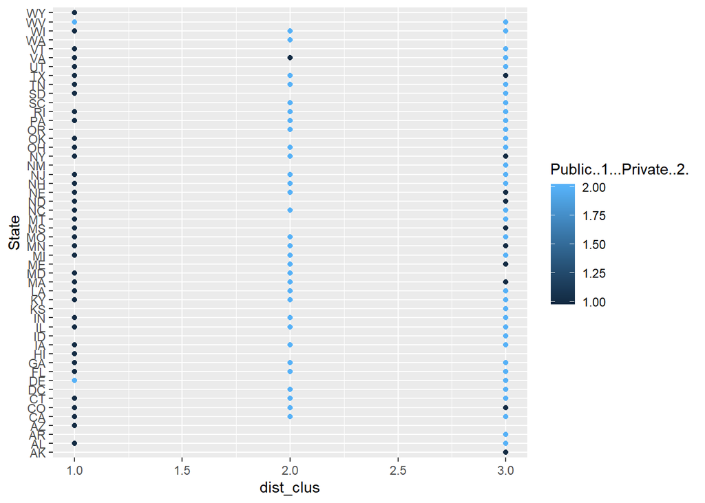

```r
# Plotting for State vs Clusters (With Public & Private)
ggplot(data_omit,aes(x= dist_clus,y = State, color = Public..1...Private..2. ))+geom_point()
```

```r
# There is a relationship between the category variable & clusters which is depicted above. Cluster 1 has the highest no of public universities & Cluster 3 has the highest no of private Universities.
```

(Question - 5) External information that can explain the contents of some or all of these clusters:

1. Ranking of the School
2. Avg Salary of Parents
3. Budget of University
4. Financial Assistance
5. Avg Salary after Graduation

(Question - 6) Step 11: Filtering the data for Tufts University

```r
Tufts <- filter(data, College.Name == "Tufts University")
```

Step 12: Calculating Euclidean Distances from respective clusters

```r
# From Cluster 1
dist(rbind(Tufts[, -c(1, 2, 3,10)], k3$centers[1,]))
```

```
##          1
## 2 29816.76
```

```r
# From Cluster 2
dist(rbind(Tufts[, -c(1, 2, 3,10)], k3$centers[2,]))
```

```
##         1
## 2 29817.8
```

```r
# From Cluster 3
dist(rbind(Tufts[, -c(1, 2, 3,10)], k3$centers[3,]))
```

```
##          1
## 2 29819.09
```

```r
# From the above results it is clear that Tufts Univ is closest to Cluster 1
```

Step 13: Imputing the missing values for Tufts by taking the average of the cluster measurements taken

```r
tufts_clus <- filter(data_omit, dist_clus == 1)
tufts_mean <- mean(tufts_clus[,c(10)])
Tufts[, c(10)] <- tufts_mean
tufts_mean
```

```
## [1] 2260.721
```